# Solutions to Chapter 2 Exercises

**3. Explore the distribution of the carat variable in the `diamonds` dataset. What binwidth reveals the most interesting patterns?**

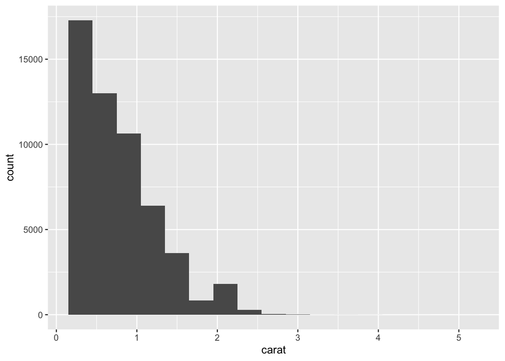

```r
diamonds %>%
  ggplot(aes(carat)) +
  geom_histogram(binwidth = 0.3)
```

- This is a subjective answer, but binwidth of 0.2 or 0.3 reveals that the distribution of `carat` is heavily skewed to the right. This means that most diamonds carats are between 0 and 1.

**4. Explore the distribution of the price variable in the `diamonds` data. How does the distribution vary by cut?**

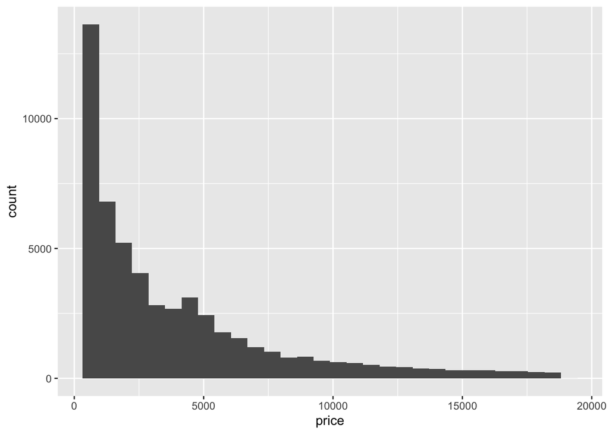

```r
diamonds %>%
  ggplot(aes(price)) +
  geom_histogram()
```

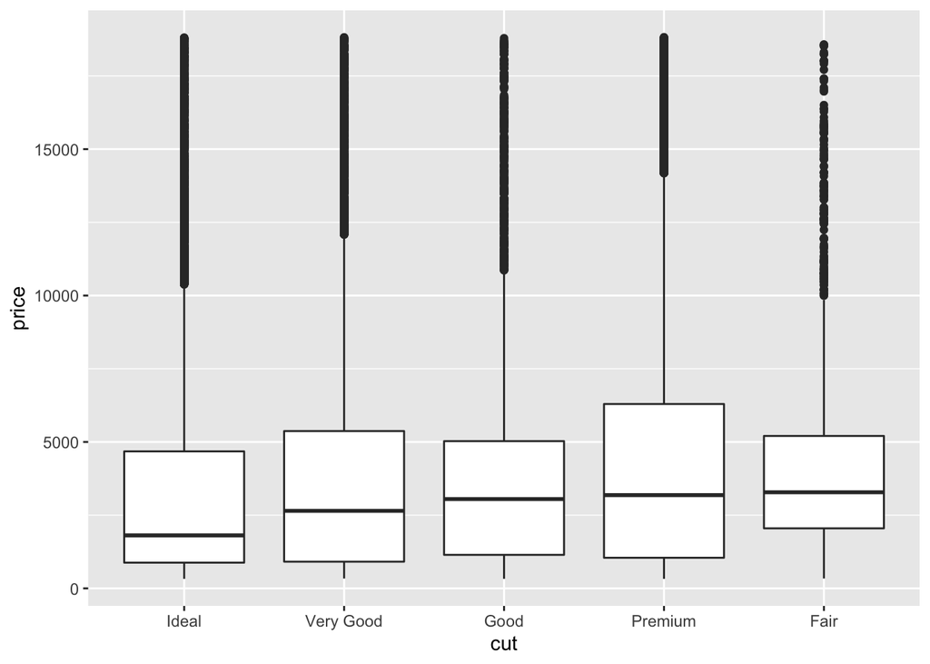

```r
diamonds %>%
  mutate(cut = fct_reorder(cut, price)) %>%
  ggplot(aes(cut, price)) +
  geom_boxplot()
```

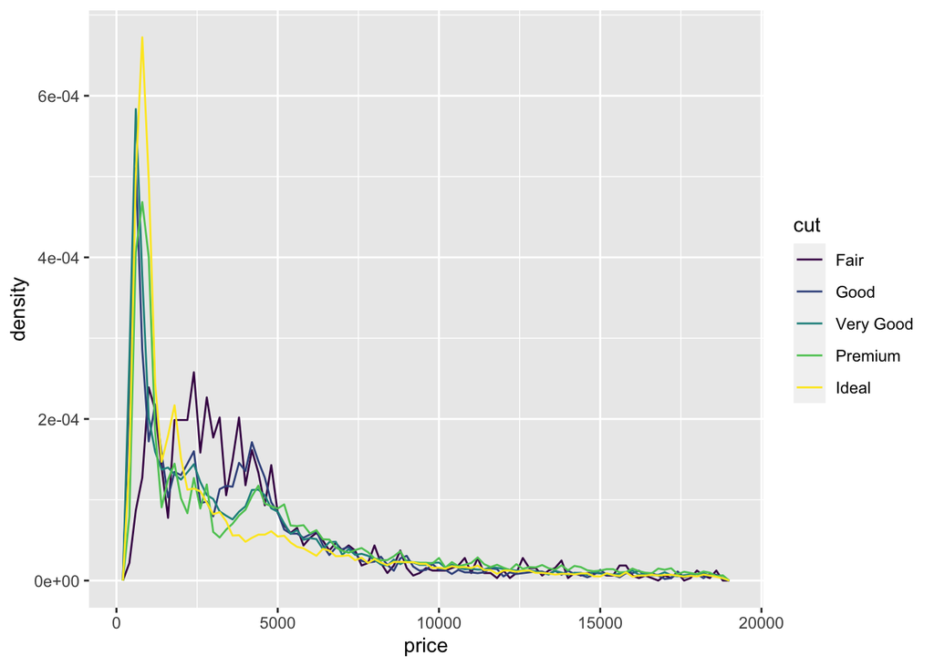

```r
ggplot(diamonds, aes(x = price, y =..density.., color = cut)) +
  geom_freqpoly(binwidth = 200)
```

- (Rademaker, 2016) Fair quality diamonds are more expensive then others. Possible reason is they are bigger.